# 12. Areas and Definite Integral

Cheng Peng

West Chester University

# 1 General Review and Exercises

- **Definition of Antiderivative**

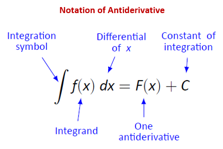

- **Basic Rules of Derivatives and Integral**.

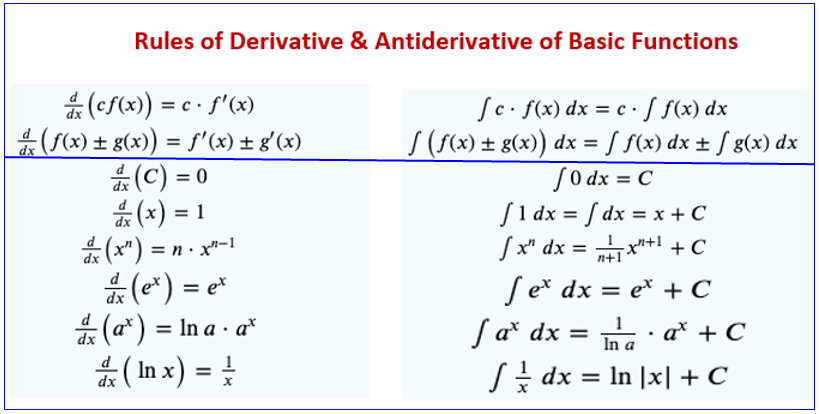

**Example 1**: Find the following integrals:

1. $\int \frac{1}{x^3}dx$.
2. $\int e^{4x}dx$
3. $\int (x^3 + 3e^x + 1/x + \sqrt[3]{x})dx$

**Solution**:

1. Rewrite the fractional function as a power function and then use the power rule.

$$\int \frac{1}{x^3} dx = \int x^{-3}dx = \frac{x^{-3 + 1}}{-3 + 1}+ C =
\frac{x^{-2}}{-2} + C = -\frac{1}{2x^2} + C.$$

2. Recall that $\int e^x dx = e^x + C$. We need to some algebraic manipulation before using the exponential rule.

$$\int e^{4x}dx = \int e^{4x} d\left(\frac{4x}{4} \right) =
\frac{1}{4}\int e^{4x} d(4x)$$

$$\stackrel{y = 4x}{=} \frac{1}{4} \int e^y dy = \frac{1}{4}(e^y + C) =
\frac{e^{4x}}{4} + C.$$

3. This problem combines several rules of integration.

$$\int (x^3 + 3e^x + 1/x + \sqrt[3]{x})dx = \int x^3 dx + 3\int e^x dx +
\int \frac{1}{x} dx + \int x^{1/3} dx$$

$$= \frac{x^{3+1}}{3+1} + 3e^x + \ln |x| + \frac{x^{1/3 + 1}}{1/3 + 1} + C
= \frac{x^4}{4} + 3e^x + \ln|x| + \frac{x^{4/3}}{4/3}$$
$$= \frac{x^4}{4} + 3e^x + \ln|x| + \frac{3x^{4/3}}{4} .$$

# 2 Areas Defined by Curves of Functions

We have learned several area formulas in algebra. For example,

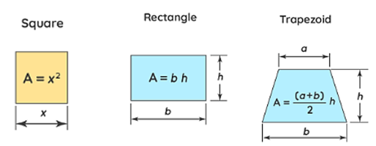

However, if have a region defined by curves and lines such as the one shown below. How find the area?

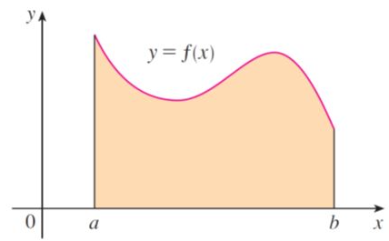

Although we don’t have a formula to find the area, however, We can approximate the area by adding up the areas of rectangles with equal width as showing in the following figure.

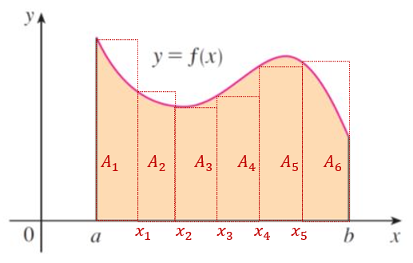

**Example 1**: Consider the graph of $f(x) = \sqrt{4-x^2}$ over the interval $[0,2]$.

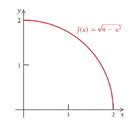

We demonstrate the accuracy of approximation using difference number of rectangles in the following. We first look at the case of 4 rectangles with the following calculation

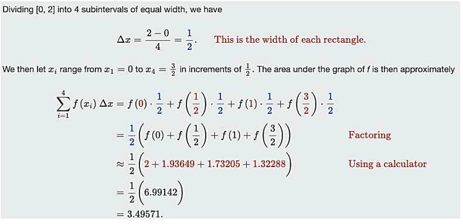

As we split the interval $[0,2]$ with more subintervals with equal width, we will get more accurate approximations.

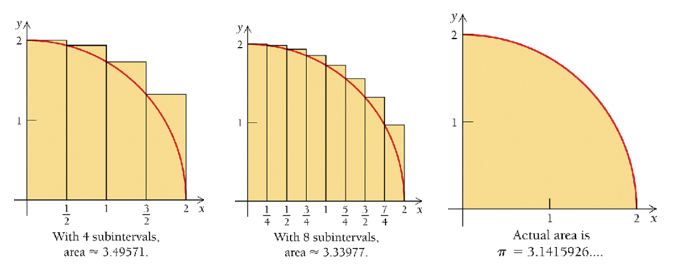

If the number of the subintervals goes to infinity, we expect to obtain the actual area - this limiting process leads to the definition of definition integral over an interval.

# 3 Definite Integral

**Definition**: Let $y = f(x)$ be continuous and non-negative over an interval $[a, b]$. A definite integral of $f(x)$ over interval $[a, b]$ is the limit as $n \to \infty$ (equivalently, the equal width $\Delta x \to 0$) of the **Riemann sum** of the areas of rectangles under the graph of $y = f(x)$ over $[a,b]$.

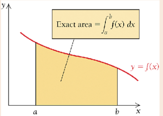

$$\text{exact area} = \lim_{\Delta x \to 0} \sum_{i=1}^n f(x_i)\Delta x =
\int_a^bf(x) dx.$$

**Caution:** The above definition assumes that the function is positive. If the function is negative over $[a,b]$, the corresponding area is negative. If a function has both negative and positive components, then negative defines negative area and the positive part defined the positive area. For example, $A_1$ is positive and $A_2$ is negative in the following figure.

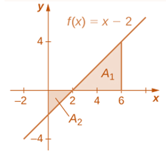

# 4 Fundmental Theorem of Calculus

To develop a technical formula to calculate the area under the curve of a positive function $f(x)$ over an interval, we define the following **following area function** $A(x)$, an antiderivative of $f(x)$, that is,

$$\frac{d A(x)}{dx} = f(x).$$

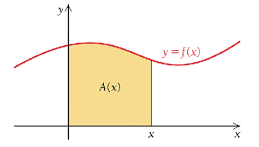

**Definition**: Let $f(x)$ be any continuous function over $[a, b]$ and $F(x)$ be any antiderivative of $f(x)$.

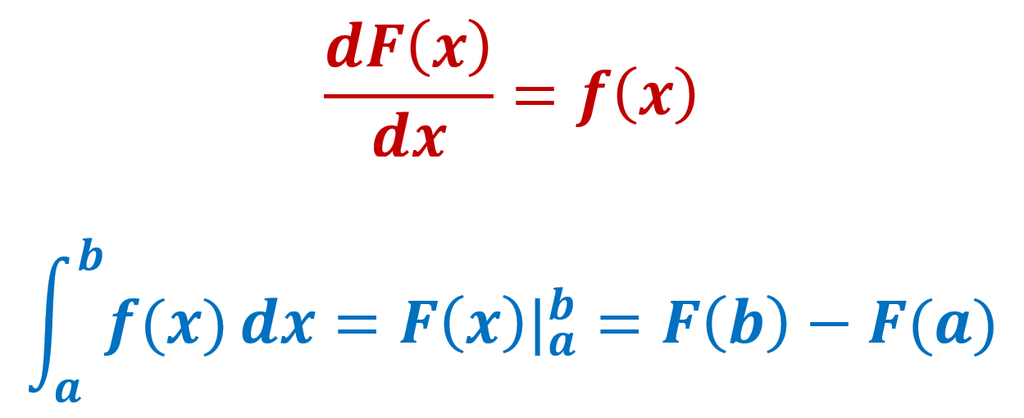

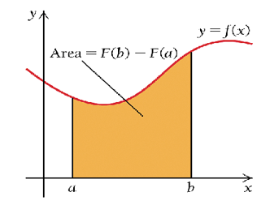

**Results from Fundamental Theorem of Calculus**

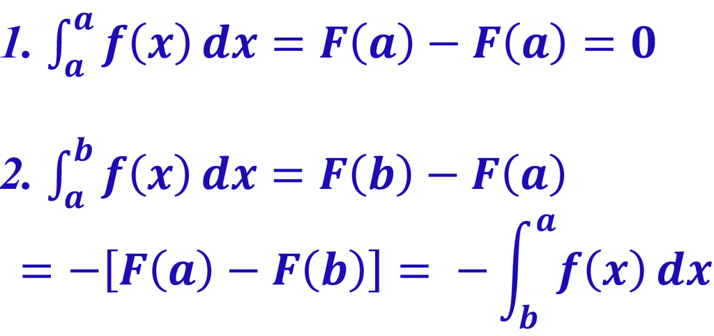

**Example 2**: Evaluate the following definite integrals

1. $\int_{-1}^4 (x^2-x)dx$
2. $\int_0^2 e^x dx$

**Solution**: Use the fundamental theorem of calculus.

1. $\int_{-1}^4 (x^2-x)dx = \int_{-1}^4 x^2 dx - \int_{-1}^4 x dx = \frac{x^3}{3}\Big|_{-1}^4 - \frac{x^2}{2}\Big|_{-1}^4=\frac{4^3 - (-1)^3}{3} - [\frac{4^2-(-1)^2}{2}] = \frac{65}{3} - \frac{15}{2} = \frac{85}{6}$.
2. $\int_0^2 e^x dx = e^x \Big|_0^2 = e^2 - 1$.

**Example 3**: *Business application* Melanie’s Crafts estimates that its sales are growing continuously at a rate given by

$$S^\prime(t) = 20 e^t,$$
where $S^\prime(t)$ is in dollars per day, on day $t$.

**Solution**: Note that the accumulated sale is given by
$$f(t) = S^\prime(t) = 20e^t.$$
1. The accumulated sales for the first 5 days the accumulated sales for the first 5 days is
$$\int_0^5f(t)dt = \int_0^5 20e^t dt = 20\int_0^5 e^t dt = 20\left(e^t
\Big|_0^5\right) = 20(e^5 - e^0) \approx 2948.26.$$

# 5 Properties of Definite Integrals

The additive property of definite integrals is summarized in the following theorem.

**Theorem 2**: For any $c$ in interval $[a, b]$,
$$\int_a^b f(x) dx = \int_a^c f(x) dx + \int_c^b f(x) dx.$$

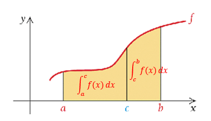

**Example 3**: Find the definite integral of $f(x)$ over interval $[-4, 4]$ where
$$f(x) = \left\{
\begin{array}{lcl}
-3\sqrt{x} & \text{for} & x > 0 \\
x & \text{for} & x \le 0
\end{array}.
\right.$$

**Solution**: Since the function on interval has two different expressions. So the additive property of integral should be used.

$$\int_{-4}^4 f(x) dx = \int_{-4}^0 f(x) dx + \int_0^4 f(x) dx =\int_0^4
-3\sqrt{x} dx + \int_{-4}^0 xdx$$
$$= -3\int_0^4 x^{1/2}dx + \int_{-4}^0 x dx =-3
\frac{x^{1/2+1}}{1/2+1}\Big|_0^4 +\frac{x^2}{2}\Big|_{-4}^0$$
$$=-3\frac{x^{3/2}}{3/2}\Big|_0^4 + \left[0 -
\frac{(-4)^2}{2}\right]=-2\sqrt{x^3}\Big|_0^4 - 8 = -16 -8 = -24$$

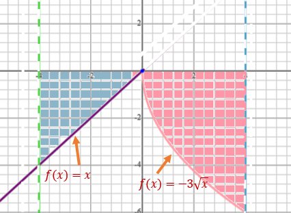

The next property is related to the area of a region bounded by two graphs.

**Theorem 3**: Let $f(x)$ and $g(x)$ to be continuous functions with $f(x) \ge g(x)$ over $[a, b]$. Then the area of the region between the two curves, from $x = a$ to $x = b$, is

$$\int_a^b [f(x) - g(x)] dx$$

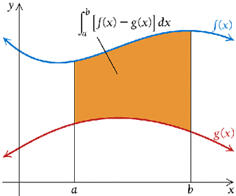

Clearly,
$$\int_a^b [f(x) - g(x)] dx = \int_a^b f(x) dx - \int_a^b g(x) dx.$$

**Example**: Find the area of the region **enclosed** by $f(x) = \sqrt{x}$ and $g(x) = x$.

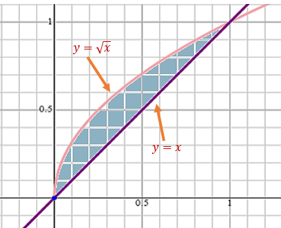

**Solution**: From the enclosed region is defined on interval $[0, 1]$. Therefore,

$$\text{eclosed area} = \int_0^1 [f(x) - g(x)] dx = \int_0^1 \sqrt{x} dx -
\int_0^1 x dx$$

$$= \frac{x^{1/2+1}}{1/2+1}\Big|_0^1 - \frac{x^2}{2}\Big|_0^1 =
\frac{1^{1/2+1}}{1/2+1} - \frac{1^2}{2} = \frac{2}{3} - \frac{1}{2} =
\frac{1}{6}.$$

# 6 Average Value of A Continuous Function

From the definition of definite integral and its geometry we can see that integrate a function over an interval is a process of taking cumulative summation. It is meaningful to define the average value of a continuous function.

**Definition** For a continuous function $f(x)$ over $[a, b]$, the average of $f(x)$ over $[a, b]$, denoted by $y_{\text{av}}$ or $\overline{f(x)}$, is defined to be

$$y_{\text{av}} = \frac{1}{b-a} \int_a^b f(x) dx$$

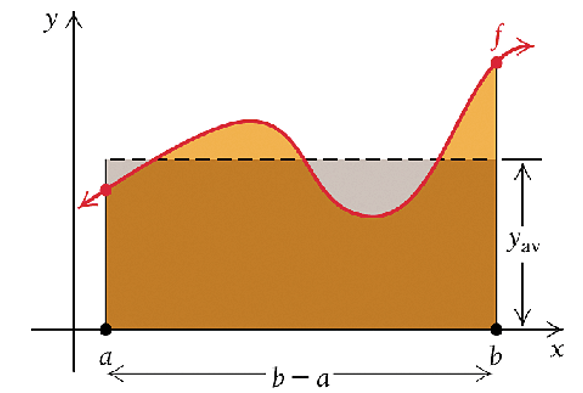

**Example 5** The population of the United States can be approximated by

$$P(t) = 310.65 e^{0.00722t},$$
where $P(t)$ is in millions and **$t$ is in the number of years since 2010**. (*Source: Population Division, U.S. Census Bureau*) Find the average size of the population from 2012 and 2019.

**Solution**: This problem is equivalent to finding the average of the population growth function over interval $[2012-2010, 2019-2010] = [2,9]$.

$$\text{average population} = \frac{1}{9-2} \int_{2}^{9}310.65
e^{0.00722t} dt$$
$$=\frac{1}{7} \times 310.65 \int_{2}^{9}e^{0.00722t}
d\left(\frac{0.00722t}{0.00722} \right)$$

$$=\frac{1}{7} \times \frac{310.65}{0.00722} \int_{2}^{9}e^{0.00722t} d
(0.00722t)$$
$$= \frac{1}{7} \times \frac{310.65}{0.00722} \times e^{0.00722t}\Big|_2^9$$
$$\approx 6146.617\times(e^{0.00722\times 9} - e^{0.00722\times 2})
\approx 323.2685$$